# 第 10 章 模型验证与超参数调优

如第 5 章到第 11 章所示，机器学习模型在训练之前需要由用户指定若干选择。这些选择包括参数值（学习率、惩罚强度等）或架构选择（例如网络结构）。机器学习引擎中的不同设计可能带来不同预测，因此选出合适设计至关重要。关于超参数调优对模型表现的影响，可参见 Probst、Bischl 和 Boulesteix（2018）的研究。对某些模型（神经网络和提升树）而言，自由度数量非常大，找到合适参数会变得复杂且具有挑战性。本章讨论这些问题，但读者必须意识到，构建好模型没有捷径。打造有效模型耗时费力，往往需要多轮迭代。

## 10.1 模型评估指标

训练前设定的参数值称为**超参数**。为了选择好的超参数，必须定义用于评估机器学习模型表现的指标。与机器学习中常见的情况一样，这里也存在一种二分：一类模型试图预测数值（回归），另一类模型试图预测类别（分类）。在介绍常见评估基准之前，我们先提到 J. Li、Liao 和 Quaedvlieg（2020）的计量经济学方法。作者提出，相对于给定基准来评估某种预测方法的表现时，应当**以某个外部变量为条件**。这有助于监控模型在何种（经济）条件下优于基准。该检验的完整实现较为复杂，感兴趣的读者可以查阅论文中的推导。

### 10.1.1 回归分析

回归任务中的预测误差通常可以直接衡量。最常用的是基于 $L^1$ 的平均绝对误差（MAE）和基于 $L^2$ 的均方误差（MSE），二者都容易计算和解释。MSE 处处可微，但直观性稍弱，而且会给予异常值更大的权重；MAE 表示预测值与已实现值之间的平均距离，但在误差为零处不可微。二者定义为

\begin{align} \tag{10.1} \text{MAE}(\textbf{y},\tilde{\textbf{y}})&=\frac{1}{I}\sum_{i=1}^I|y_i-\tilde{y}_i|, \\ \tag{10.2} \text{MSE}(\textbf{y},\tilde{\textbf{y}})&=\frac{1}{I}\sum_{i=1}^I(y_i-\tilde{y}_i)^2, \end{align}

而 RMSE 只是 MSE 的平方根。我们总可以通过加入权重 $w_i$ 来推广这些公式，使不同样本的重要性具有异质性。这里简要评论一下 MSE。它是机器学习中最常见的损失函数，但在组合配置任务中用于收益预测时，它并不一定是精确意义上的最佳选择。如果把损失分解为 3 项，就得到已实现收益平方和、预测收益平方和，以及二者的乘积项（粗略地说，如果假设均值为零，这一项类似协方差项）。第一项无关紧要。第二项控制预测值围绕零的离散程度。第三项从配置者角度看最有意思。交叉乘积 $-2y_i\tilde{y}_i$ 为负总是对投资者有利：要么两项都为正，模型识别出盈利资产；要么两项都为负，模型识别出糟糕机会。只有当 $y_i$ 与 $\tilde{y}_i$ 符号不一致时，问题才会出现。因此，相比 $\tilde{y}_i^2$，交叉项更重要。尽管如此，算法并不是针对这一指标进行优化的。21

这些指标（MSE 和 RMSE）在机器学习之外也被广泛用于评估预测误差。下面，我们介绍一些有时也用于量化模型质量的其他指标。与线性回归一致，$R^2$ 可以在任何预测任务中计算。

\begin{equation} \tag{10.3} R^2(\textbf{y},\tilde{\textbf{y}})=1- \frac{\sum_{i=1}^I(y_i-\tilde{y}_i)^2}{\sum_{i=1}^I(y_i-\bar{y})^2}, \end{equation}

其中 $\bar{y}$ 是标签的样本均值。它与经典 $R^2$ 的一个重要差异在于，上式可以在**测试样本**而非**训练样本**上计算。在这种情况下，当分子中的均方误差大于测试样本的（有偏）方差时，$R^2$ 可以为负。有时，分母中的均值项 $$\bar{y}$ $ 会被省略（例如 Gu、Kelly 和 Xiu（2020b））。去掉均值项的好处是，它把模型预测与零预测进行比较。这对收益尤其相关，因为最简单的预测就是恒为零，此时 $R^2$ 可以衡量模型是否优于这个朴素基准。零预测总是优于样本均值，因为后者可能高度依赖样本区间。此外，去掉分母中的 $\bar{y}$ 会机械地降低 $R^2$，从而使指标更保守。

除上述简单指标外，还存在若干较少见的扩展，它们的共同点都是先对误差做变换，再取平均。两个典型例子是平均绝对百分比误差（MAPE）和均方百分比误差（MSPE）。它们不是考察原始误差，而是计算相对于原始值（待预测值）的误差。因此，误差以百分比得分表示，平均值为：

\begin{align} \tag{10.4} \text{MAPE}(\textbf{y},\tilde{\textbf{y}})&=\frac{1}{I}\sum_{i=1}^I\left|\frac{y_i-\tilde{y}_i}{y_i}\right|, \\ \tag{10.5} \text{MSPE}(\textbf{y},\tilde{\textbf{y}})&=\frac{1}{I}\sum_{i=1}^I\left(\frac{y_i-\tilde{y}_i}{y_i}\right)^2, \end{align}

其中后者如有需要可以再开平方。当标签为正且可能取较大值时，可以对误差幅度进行缩放，否则误差可能非常大。一种做法是使用均方根对数误差（RMSLE），定义如下：

\begin{equation} \tag{10.6} \text{RMSLE}(\textbf{y},\tilde{\textbf{y}})=\sqrt{\frac{1}{I}\sum_{i=1}^I\log\left(\frac{1+y_i}{1+\tilde{y}_i}\right)}, \end{equation}

当 $y_i=\tilde{y}_i$ 时，该误差指标等于零。

在转向类别型损失之前，我们简要评论 MSE 的一个缺点。MSE 是回归任务中最广泛使用的指标和目标函数。一个简单分解给出：

\begin{align} \text{MSE}(\textbf{y},\tilde{\textbf{y}})=\frac{1}{I}\sum_{i=1}^I(y_i^2+\tilde{y}_i^2-2y_i\tilde{y}_i). \end{align}

在求和式中，第一项是给定的，无法改变，因此模型会集中最小化另外两项。第二项是模型取值的离散程度。第三项是交叉乘积。虽然 $\tilde{y}_i$ 的变化确实重要，但第三项尤其在横截面中远为关键。通过提高 $y_i\tilde{y}_i$ 来降低 MSE 更有价值。当两项符号相同时，这个乘积为正，而这正是投资者寻找的东西：下注方向**正确**。对某些算法（如神经网络），可以手动指定自定义损失。最大化 $y_i\tilde{y}_i$ 的和，可能是普通二次优化的良好替代方案（实现示例见第 7.4.3 节）。

### 10.1.2 分类分析

类别型输出的表现指标与数值型输出的指标有很大不同。相当多指标专门用于二分类，不过其中一些也可以容易地推广到多分类模型。

我们按复杂度递增的顺序介绍这些指标，先区分正类与负类，以及预测正确与预测错误。在投资场景中，可以把正类定义为收益率为正或高于某个基准，负类则表示相反情形。

因此，一次预测可能产生 4 种结果。预测正确时有两种（预测为真且实现为真，或预测为假且结果为假），预测错误时也有两种（预测为真但实现为假，以及相反情形）。我们在下方定义相应的汇总指标：

- 真阳性比例：$TP=I^{-1}\sum_{i=1}^I1_{\{y_i=\tilde{y}_i=1 \}},$
- 真阴性比例：$TN=I^{-1}\sum_{i=1}^I1_{\{y_i=\tilde{y}_i=0 \}},$
- 假阳性比例：$FP=I^{-1}\sum_{i=1}^I1_{\{\tilde{y}_i=1,y_i=0 \}},$
- 假阴性比例：$FN=I^{-1}\sum_{i=1}^I1_{\{\tilde{y}_i=0,y_i=1 \}},$

其中，按照惯例，真编码为 1，假编码为 0。四个数之和等于一。如图 10.1 所示，这四个数字对样本外结果的影响非常不同。在这张表（也称为**混淆矩阵**）中，假设模型预测的是未来盈利性的某种代理变量。每一行表示模型预测，每一列表示盈利性的实现。最重要的是第一行中的情况，即模型预测结果为正，因为具有正预测盈利性（可能相对于某个基准）的资产很可能会进入组合。当然，如果资产表现良好（左侧单元格），这不是问题；但如果模型出错，组合会承受损失，因而会受到惩罚。

[figure not shown]

图 10.1：混淆矩阵：二元结果汇总。

在两类错误中，**I 类错误**对投资者最令人担忧，因为它会直接影响组合。**II 类错误**只是错失机会，影响相对较小。最后，真负例是那些被正确排除在组合之外的资产。

由这四个基准比率可以推导出其他有用指标：

- **准确率** = $TP+TN$，即正确预测的百分比；
- **召回率** = $\frac{TP}{TP+FN}$，衡量发现优胜策略/资产的能力（左列分析）。也称为敏感度或真正例率（TPR）；
- **精确率** = $\frac{TP}{TP+FP}$，计算优质投资的概率（第一行分析）；
- **特异度** = $\frac{TN}{FP+TN}$，衡量实际负例被正确识别为负例的比例（右列分析）；
- **误报率** = $\frac{FP}{FP+TN}=1-$ 特异度，即虚警概率（或假正例率），也就是算法错误地识别出表现资产的频率（右列分析）；
- **F 分数**，$\mathbf{F}_1=2\frac{\text{recall}\times \text{precision}}{\text{recall}+ \text{precision}}$，是召回率和精确率的调和平均。

所有这些指标都位于单位区间内，数值越高，通常认为模型表现越好（误报率除外，它越低越好）。还存在许多其他指标，例如假发现率或假遗漏率，但它们不那么主流，被引用也较少。此外，它们往往只是上述指标的简单函数。

一个流行但更复杂的指标是 ROC 曲线下面积，通常称为 AUC。复杂之处在 ROC 曲线本身，ROC 代表受试者工作特征（Receiver Operating Characteristic），这一名称来自信号理论。下面解释它如何构造。

如第 6 章和第 7 章所见，分类器生成的输出是某个样本属于某一类别的概率。随后通过选择概率最高的类别，将这些概率转换成类别。在二分类中，分数高于 0.5 的类别基本上会胜出。

实践中，0.5 这个阈值未必最优；模型完全可能在预测概率低于 0.4 时把样本判为负类，其余样本判为正类。因此，自然要考察决策阈值变化时分类结果如何变化。ROC 曲线正是为此而设：当阈值从 0 增加到 1 时，它以误报率为横轴、召回率为纵轴绘制曲线。

按照“预测概率高于阈值即判为正类”的惯例，当阈值为 0 时，所有样本都被判为正类，因此召回率和假阳性率均为 1；当阈值为 1 时，所有样本都被判为负类，因此二者均为 0。两个极端之间形成的轨迹称为 ROC 曲线。图 10.2 给出了一个示意图。随机分类器的召回率与假阳性率相同，所以 ROC 曲线是连接点 (0,0) 与 (1,1) 的对角线。为说明这一点，设样本中正类比例为 $p\in (0,1)$，分类器以概率 $p'\in (0,1)$ 随机预测为正类。由于真实类别与预测相互独立，$TP=p'p$，$FP = p'(1-p)$，$TN=(1-p')(1-p)$，$FN=(1-p')p$。根据上述定义，召回率和假阳性率都等于 $p'$。

[figure not shown]

图 10.2：风格化 ROC 曲线。

ROC 曲线位于 45° 线之上的算法优于平均分类器。事实上，这条曲线可以看作收益（在 $y$ 轴上发现好策略的概率）减去成本（在 $x$ 轴上选错资产的概率）之间的权衡。因此，位于 45° 线上方至关重要。最好的分类器的 ROC 曲线从点 (0,0) 到点 (0,1) 再到点 (1,1)。在点 (0,1)，误报率为零，因此没有假正例；召回率等于一，因此也没有假负例：模型总是正确。反过来也成立：在点 (1,0)，模型总是错误。

下面，我们针对测试样本上的一组给定预测计算 ROC 曲线。

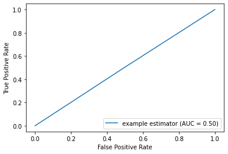

```python
from sklearn.metrics import roc_curve, RocCurveDisplay, auc # Module for AUC computation
import matplotlib.pyplot as plt
import numpy as np

fpr, tpr, thresholds = roc_curve(testing_sample['R1M_Usd_C'].values,
                                 fit_RF_C.predict(testing_sample[features]))
roc_auc = auc(fpr, tpr)
display = RocCurveDisplay(fpr=fpr, tpr=tpr, roc_auc=roc_auc,
                                  estimator_name='example estimator')
display.plot()
plt.show()
```

图 10.3：ROC 曲线示例。

```python
print(f'AUC: {roc_auc}')
```

```
AUC: 0.5021678143170378
```

在图 10.3 中，曲线非常接近 45° 线，模型看起来与随机分类器一样好（或者更准确地说，一样差）。

最后，在比较时保留整条曲线并不方便，因此整条曲线的信息被概括为曲线下面积，即相应函数的积分。45° 线（象限平分线）的面积为 0.5（它是单位正方形的一半）。因此，任何好模型的曲线下面积（AUC）都应高于 0.5。完美模型的 AUC 为一。

本小节最后谈一下多分类数据。当输出（即标签）具有两个以上类别时，事情会变得更复杂。仍然可以计算混淆矩阵，但维度更高且更难解释。$TP$、$TN$ 等简单指标必须以非标准方式推广。在这种情况下，最简单的指标是式 (7.5) 中定义的交叉熵。关于类别标签相关损失的更多细节，可参见第 6.1.2 节。

## 10.2 验证

验证是模型在开始部署到真实或实时数据（例如用于交易）之前进行测试和超参数调优的阶段。不用说，它至关重要。

### 10.2.1 方差-偏差权衡：理论

**方差-偏差权衡**是监督学习中的核心概念之一。为解释它，我们假设数据由如下简单模型生成：

\begin{align} y_i=f(\textbf{x}_i)+\epsilon_i, \quad \mathbb{E}[\boldsymbol{\epsilon}]=0, \quad \mathbb{V}[\boldsymbol{\epsilon}]=\sigma^2, \end{align}

但估计得到的模型为

\begin{align} y_i=\hat{f}(\textbf{x}_i)+\hat{\epsilon}_i. \end{align}

对于一条未见过的输入观测 $\textbf{x}$，平均平方误差可分解为

\begin{align} \tag{10.7} \mathbb{E}[\hat{\epsilon}^2]&=\mathbb{E}[(y-\hat{f}(\textbf{x}))^2]=\mathbb{E}[(f(\textbf{x})+\epsilon-\hat{f}(\textbf{x}))^2] \\ &= \underbrace{\mathbb{E}[(f(\textbf{x})-\hat{f}(\textbf{x}))^2]}_{\text{total quadratic error}}+\underbrace{\mathbb{E}[\epsilon^2]}_{\text{irreducible error}} \nonumber \\ &= \mathbb{E}[\hat{f}(\textbf{x})^2]+\mathbb{E}[f(\textbf{x})^2]-2\mathbb{E}[f(\textbf{x})\hat{f}(\textbf{x})]+\sigma^2\nonumber\\ &=\mathbb{E}[\hat{f}(\textbf{x})^2]+f(\textbf{x})^2-2f(\textbf{x})\mathbb{E}[\hat{f}(\textbf{x})]+\sigma^2\nonumber\\ &=\left[ \mathbb{E}[\hat{f}(\textbf{x})^2]-\mathbb{E}[\hat{f}(\textbf{x})]^2\right]+\left[\mathbb{E}[\hat{f}(\textbf{x})]^2+f(\textbf{x})^2-2f(\textbf{x})\mathbb{E}[\hat{f}(\textbf{x})]\right]+\sigma^2\nonumber\\ &=\underbrace{\mathbb{V}[\hat{f}(\textbf{x})]}_{\text{variance of model}}+ \quad \underbrace{\mathbb{E}[(f(\textbf{x})-\hat{f}(\textbf{x}))]^2}_{\text{squared bias}}\quad +\quad\sigma^2 \nonumber \end{align}

在上述推导中，$f(x)$ 不是随机的，但 $\hat{f}(x)$ 是随机的。此外，在第二行中，我们假设 $\mathbb{E}[\epsilon(f(x)-\hat{f}(x))]=0$，这一点未必总成立（尽管它是非常常见的假设）。因此，平均平方误差包含三个组成部分：

- 模型（预测值）的方差；
- 模型的偏差平方；
- 以及一个**不可约误差**（与具体模型选择无关）。

最后一项不受模型改变影响，因此挑战在于最小化前两项之和。这就是所谓的方差-偏差权衡，因为降低其中一项往往会提高另一项。因此，目标是评估在什么时候某一项的小幅增加能够换来另一项更大幅度的下降。

有几种方式可以表示这种权衡，我们展示其中两种。第一种与射箭有关（见下方图 10.4）。最好情形（左上）是所有射击都集中在中心：平均而言，射手瞄得准，所有箭彼此也非常接近。最差情形（右下）正好相反：平均箭着点在靶心上方（偏差不为零），且箭的离散程度很大。

[figure not shown]

图 10.4：方差-偏差权衡的第一种表示。

机器学习中最常见的是另外两种配置：要么箭（预测）集中在一个小范围内，但这个范围不是靶心；要么箭平均而言围绕靶心分布良好，但平均距离靶心较远。

方差-偏差权衡也常用模型复杂度来说明。最简单的是常数模型：它始终给出同一个预测值，例如训练集标签的均值。这类预测往往与测试集的实际标签相差较大，因此偏差很高，但预测方差为零。另一端是叶子数与样本数相同的决策树，其结构极其复杂。它的偏差可能更小，但复杂度带来的方差增幅未必能由偏差降幅抵消。

图 10.5 展示了这一权衡的这个侧面。在图左侧，简单模型方差小但偏差大；在右侧，复杂模型则相反。好模型往往位于中间某处，但最佳组合很难找到。

[figure not shown]

图 10.5：方差-偏差权衡的第二种表示。

方差-偏差权衡最易处理的理论形式是岭回归。22 这种回归中的系数估计量为 $\hat{\mathbf{b}}_\lambda=(\mathbf{X}'\mathbf{X}+\lambda \mathbf{I}_N)^{-1}\mathbf{X}'\mathbf{Y}$（见第 5.1.1 节），其中 $\lambda$ 是惩罚强度。假设数据生成过程具有真实线性形式（$\textbf{y}=\textbf{Xb}+\boldsymbol{\epsilon}$，其中 $\textbf{b}$ 未知，$\sigma^2$ 是误差方差，且误差相关矩阵为单位矩阵），则得到

\begin{align} \mathbb{E}[\hat{\textbf{b}}_\lambda]&=\textbf{b}-\lambda(\textbf{X}'\textbf{X}+\lambda \textbf{I}_N)^{-1} \textbf{b}, \\ \tag{10.8} \mathbb{V}[\hat{\textbf{b}}_\lambda]&=\sigma^2(\textbf{X}'\textbf{X}+\lambda \textbf{I}_N)^{-1}\textbf{X}'\textbf{X} (\textbf{X}'\textbf{X}+\lambda \textbf{I}_N)^{-1}. \end{align}

基本上，这意味着估计量的偏差等于 $-\lambda(\textbf{X}'\textbf{X}+\lambda \textbf{I}_N)^{-1} \textbf{b}$；在没有惩罚（经典回归）时它为零，并在 $\lambda \rightarrow \infty$、即模型变成常数时收敛到某个有限数。注意，如果估计量偏差为零，则预测的偏差也为零：$\mathbb{E}[\textbf{X}(\textbf{b}-\hat{\textbf{b}})]=\textbf{0}$。

在无约束回归中，估计量方差等于 $\mathbb{V}[\hat{\textbf{b}}]=\sigma (\textbf{X}'\textbf{X})^{-1}$。在式 (10.8) 中，$\lambda$ 会降低逆矩阵中数值的幅度。总体效果是，随着 $\lambda$ 增大，方差下降；在极限 $\lambda \rightarrow \infty$ 下，模型为常数，方差为零。预测的方差为

\begin{align*} \mathbb{V}[\textbf{X}\hat{\textbf{b}}]&=\mathbb{E}[(\textbf{X}\hat{\textbf{b}}-\mathbb{E}[\textbf{X}\hat{\textbf{b}}])(\textbf{X}\hat{\textbf{b}}-\mathbb{E}[\textbf{X}\hat{\textbf{b}}])'] \\ &= \textbf{X}\mathbb{E}[(\hat{\textbf{b}}-\mathbb{E}[\hat{\textbf{b}}])(\hat{\textbf{b}}-\mathbb{E}[\hat{\textbf{b}}])']\textbf{X}' \\ &= \textbf{X}\mathbb{V}[\hat{\textbf{b}}]\textbf{X} \end{align*}

总体而言，岭回归非常方便，因为借助单个参数，它们就能提供一个直接调节方差-偏差权衡的游标。

用岭回归展示这种权衡有多简单很容易说明。在下面的例子中，我们复用第 5 章训练的岭模型。

```
array([<AxesSubplot:xlabel='Lambda'>, <AxesSubplot:xlabel='Lambda'>,
       <AxesSubplot:xlabel='Lambda'>], dtype=object)
```

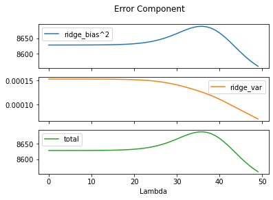

```python
### recalling variable from chapter 5
ridge_bias = []
ridge_var = []
for alpha in range(0,len(alphas),1):
    predictions=np.dot((df_ridge_res.iloc[alpha,:].values),X_penalized.T)
    ridge_bias.append(np.sum(np.square(predictions - y_penalized)))
    ridge_var.append(np.var(predictions))
df = pd.DataFrame(list(zip(ridge_bias, ridge_var)),
               columns =['ridge_bias^2', 'ridge_var'])
df['total']=df['ridge_bias^2']+df['ridge_var']
df.plot(subplots=True,title='Error Component',xlabel='Lambda')
```

图 10.6：岭回归的误差分解。

在图 10.6 中，模式不同于图 10.5 所描绘的模式。在图中，当强度 lambda 增加时，参数幅度收缩，模型变得更简单。因此，最简单的模型似乎是最佳选择：增加复杂度提高了方差，却没有改善偏差！一个可能原因是特征实际上没有携带太多预测价值，因此常数模型与基于无关变量的更复杂模型一样好。

### 10.2.2 方差-偏差权衡：示例

方差-偏差权衡通常以容易理解的理论术语呈现。不过，展示它如何体现在真实算法选择上仍然有用。下面，我们以树为例，因为树的复杂度容易评估。基本上，具有许多终端节点的树比只有少数簇的树更复杂。

我们先从简约模型开始，并在下方训练它。

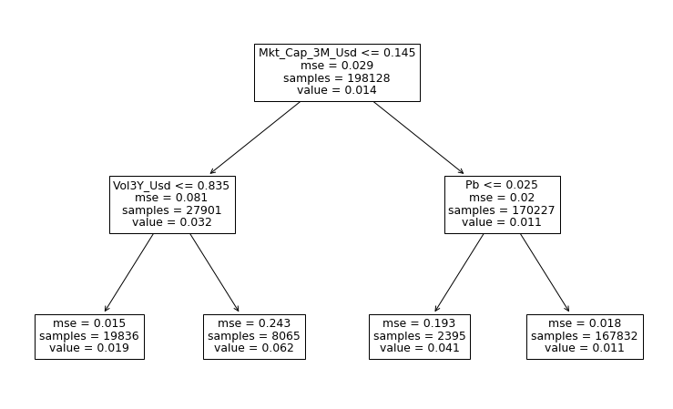

```python
from sklearn import tree # Tree module
import matplotlib.pyplot as plt # to adjust tree plot

X = training_sample[features] # recall features/predictors, full sample
y = y_train # recall label/Dependent variable, full sample

fit_tree_simple = tree.DecisionTreeRegressor( # Definining the model
  max_depth = 2, # Maximum depth (i.e. tree levels)
  ccp_alpha=0.000001, # complexity parameters
        )
fit_tree_simple.fit(X, y) # Fitting the model
fig, ax = plt.subplots(figsize=(13, 8)) # resizing
tree.plot_tree(fit_tree_simple,feature_names=X.columns.values, ax=ax) # Plot the tree
plt.show()
```

图 10.7：简单树。

图 10.7 中的模型只有 4 个簇，这意味着预测只能取四个值。最小值为 0.011，覆盖样本的大部分（85%）；最大值为 0.062，只对应训练样本的 4%。 随后，我们可以在测试集上计算预测的偏差和方差。

```python
bias_tree = np.mean(fit_tree_simple.predict(X_test) - y_test)
print(f'bias: {bias_tree}')
```

```
bias: 0.004973916538330352
```

```python
var_tree = np.var(fit_tree_simple.predict(X_test))
print(f'var: {var_tree}')
```

```
var: 0.0001397982854475224
```

平均而言，误差略为正，总体高估为 0.005。正如预期，方差非常小（$10^{-4}$）。

对于复杂模型，我们采用第 6.4.6 节得到的提升树（fit_xgb）。该模型聚合了 40 棵树，最大深度为 4，因此无疑更加复杂。

```python
bias_xgb = np.mean(fit_xgb.predict(test_matrix_xgb) - y_test)
print(f'bias: {bias_xgb}')
```

```
bias: 0.019378203027941212
```

```python
var_xgb = np.var(fit_xgb.predict(test_matrix_xgb))
print(f'var: {var_xgb}')
```

```
var: 0.0011795820901170373
```

### 10.2.3 过拟合风险：原理

**过拟合**是机器学习中最重要的概念之一。当模型过拟合时，其预测准确性会令人失望，因此这是某些策略在样本外失效的主要原因之一。因此，重要的不仅是理解什么是过拟合，还要理解如何缓解其影响。

关于这一主题及其对组合策略影响的近期参考是 Hsu 等（2018），其建立在 White（2000）的工作之上。这两篇文献都不处理机器学习模型，但原理相同。给定一个数据集后，足够深入的分析（无论由人还是机器完成）总能检测出某些模式。这些模式是否虚假，才是关键问题。

图 10.8 用一个简单的可视化例子说明这一想法。我们试图找到一个把 x 映射到 y 的模型。（训练）数据点是小黑圆圈。最简单的模型是常数模型（只有一个参数），但有两个参数（截距和斜率）时，拟合已经相当不错。蓝线展示了这一点。只要参数数量足够，就可以构建一个穿过所有点的模型。一个例子是高维多项式。红线展示了这样一个模型。现在数据集中似乎有一个异常点，而复杂模型紧密贴合它。

[figure not shown]

图 10.8：过拟合示意：模型紧贴训练数据通常不是好主意。

浅绿色表示一个新增点。可以说，它遵循其他点的一般模式。简单模型并不完美，误差也不可忽视。然而，复杂模型产生的误差（以灰色虚线表示）大约是其两倍。这个简化例子表明，过于贴近训练数据的模型会捕捉到不会出现在其他数据集中的特异性。好模型应忽略这些特异性，坚持数据中持久存在的结构。

### 10.2.4 过拟合风险：一些解决方案

避免过拟合最简单的方法，是抵制使用复杂模型（例如高维神经网络或树集成）的诱惑。

模型复杂度通常用两个度量来近似：模型参数数量及其幅度（通常通过范数概括）。这些代理并不完美，因为某些复杂模型可能只需要少量参数（甚至较小参数值），但至少它们直观且易于处理。处理过拟合并没有通用方法。下面，我们针对若干类机器学习工具介绍一些技巧。

对**回归**而言，有两种简单方法可以处理过拟合。第一是控制参数数量，即预测变量数量。有时只选择特征子样本会更好，尤其是在某些特征高度相关时（通常，特征之间绝对相关性超过 70% 会被认为过高）。第二种方案是惩罚化（通过 LASSO、ridge 或 elasticnet），它有助于降低估计值的幅度，从而降低预测方差。

对基于树的方法而言，有多种方式可以降低过拟合风险。处理**简单树**时，唯一方法是限制叶子数量。这可以通过多种方式完成。首先，可以施加最大深度。如果它等于 $d$，则树最多有 $2^d$ 个终端节点。通常建议不要超过 $d=6$。rpart 中的复杂度参数（cp）是另一种收缩树规模的方法：任何新分裂都必须带来至少等于 cp 的损失降低。否则，该分裂不会被认为有用，也就不会执行。因此，当 cp 很大时，树不会继续生长。rpart 中最后两个可用参数是每个叶子所需的最小样本数，以及为了继续分裂过程而要求每个簇具有的最小样本数。这些数值越高（即约束越强），越难生成复杂树。

除这些选项外，**随机森林**还允许控制森林中树的数量。从理论上讲（见 Breiman（2001）），该参数不应影响过拟合风险，因为新增树只会通过分散化帮助降低总误差。实践中，考虑到计算时间，不建议超过 1,000 棵树。另外两个超参数是子样本大小（每个学习器的训练样本量）和每次学习保留的特征数量。它们并不直接改变偏差-方差权衡，而是更多地影响模型的基本表现。例如，子样本过小会使树无法学到足够信息，特征数量过少也有同样问题。另一方面，选择过多预测变量（即接近变量总数）可能使各学习器的预测高度相关，因为它们使用的训练信息高度重叠。

**提升树**还有其他选项可帮助缓解过拟合风险。最明显的是学习率，它以 $\eta \in (0,1)$ 折扣每棵新树的影响。当学习率很高时，算法学习过快，容易紧贴训练数据。当学习率较低时，模型学习非常渐进；如果集成中有足够多的树，这可能很有效。事实上，学习率和树的数量必须同步选择：如果二者都低，集成学不到东西；如果二者都高，则会过拟合。提升树参数库不止于此。对得分值和叶子数量的惩罚，自然也是防止模型过度深入训练样本特殊性的工具。最后，第 6.4.5 节提到的单调性约束也是给模型施加某种结构、迫使其检测特定模式的有效方式。

最后，**神经网络**也有许多旨在防止过拟合的选项。与提升树一样，其中一些选项是学习率以及对权重和偏置（通过其范数）的惩罚。约束（如非负约束）在模型理论上要求正输入时也会有帮助。最后，Dropout 始终是降低网络维度（参数数量）的直接方法。

## 10.3 寻找良好超参数

### 10.3.1 方法

假设模型运行前需要定义 $p$ 个参数。最简单的做法是测试这些参数的不同取值，并选择结果最好的组合。执行这些测试主要有两种方式：独立地测试和顺序地测试。

独立测试很容易，分为两类：网格（确定性）搜索和随机探索。确定性方法的优点是能均匀覆盖空间，并确保不会遗漏角落。缺点是计算时间。事实上，对每个参数，测试至少五个取值似乎是合理的，这会产生 $5^p$ 个组合。如果 $p$ 较小（小于 3），且回测不太长，这是可管理的。当 $p$ 很大时，组合数可能变得不可承受。这时随机探索会有用，因为用户可以事先指定测试次数，而参数随机抽取（通常在每个参数的给定范围内均匀抽取）。随机搜索的缺陷是参数空间中的某些区域可能没有被覆盖；如果最佳选择位于那里，就会有问题。不过 Bergstra 和 Bengio（2012）表明，随机探索优于网格搜索。

网格搜索和随机搜索都不是最优的，因为它们很可能把时间花在参数空间中无关的区域，从而浪费计算时间。在已经测试了一些参数点之后，更可取的是把搜索集中在最优点更可能出现的区域。这可以通过一个迭代过程实现：每测试一个新点后调整搜索。在金融这一广阔领域中，专门讨论超参数调优的论文包括 Lee（2020）以及 Nystrup、Lindstrom 和 Madsen（2020）。

朝这个方向的另一种流行方法是**贝叶斯优化**（BO）。核心对象是学习过程的目标函数。我们称该函数为 $O$，它可以广义地看作一个可能结合惩罚和约束的损失函数。为简单起见，这里不再提训练/测试样本，并将其视为固定。感兴趣的变量是向量 $\textbf{p}=(p_1,\dots,p_l)$，它概括了对 $O$ 有影响的超参数（学习率、惩罚强度、模型数量等）。我们关注的程序为

\begin{equation} \tag{10.9} \textbf{p}_*=\underset{\textbf{p}}{\text{argmin}} \ O(\textbf{p}). \end{equation}

这一优化的主要问题在于计算 $O(\textbf{p})$ 非常昂贵。因此，明智地选择每一次 $\textbf{p}$ 试验至关重要。BO 的一个关键假设是 $O$ 的分布为高斯，并且 $O$ 可以由 $p_l$ 的线性组合近似。换言之，目标是在输入 $\textbf{p}$ 与输出（因变量）$O$ 之间构建贝叶斯线性回归。一旦模型估计完成，便利用集中在 $O$ 后验密度中的信息，对在哪里寻找新的 $\textbf{p}$ 取值作出有根据的猜测。

这种有根据的猜测基于所谓**采集函数**。假设我们已经测试了 $m$ 个 $\textbf{p}$ 取值，记为 $\textbf{p}^{(m)}$。当前最佳参数写作 $\textbf{p}_m^*=\underset{1\le k\le m}{\text{argmin}} \ O(\textbf{p}^{(k)})$。如果测试一个新点 $\textbf{p}$，只有当 $O(\textbf{p})<O(\textbf{p}_m^*)$ 时，它才会带来改进，也就是新的目标值改善了已知的最小值。该改进的平均值为

\begin{equation} \tag{10.10} \textbf{EI}_m(\textbf{p})=\mathbb{E}_m[[O(\textbf{p}_m^*)-O(\textbf{p})]_+], \end{equation}

其中正部 $[\cdot]_+$ 强调，当 $O(\textbf{p})\ge O(\textbf{p}_m^*)$ 时，改进量为零。期望以下标 $m$ 标记，因为它是基于 $m$ 个样本 $\textbf{p}^{(m)}$，相对于 $O(\textbf{p})$ 的后验分布计算的。下一个样本 $\textbf{p}^{(m+1)}$ 的最佳选择随后为

\begin{equation} \tag{10.11} \textbf{p}^{m+1}=\underset{\textbf{p}}{\text{argmax}} \ \textbf{EI}_m(\textbf{p}), \end{equation}

这对应于期望改进的最大位置。除了 EI，也可以用其他度量进行优化，例如改进概率，即 $\mathbb{P}_m[O(\textbf{p})<O(\textbf{p}_m^*)]$。

用紧凑形式表示，迭代过程可概述如下：

- **步骤 1**：对 $m=1,\dots,M_0$ 个参数取值计算 $O(\textbf{p}^{(m)})$。
- **步骤 2a**：在所有可用点上顺序计算 $O$ 的后验密度。
- **步骤 2b**：计算式 (10.11) 给出的待测试最优新点 $\textbf{p}^{(m+1)}$。
- **步骤 2c**：计算新的目标值 $O(\textbf{p}^{(m+1)})$。
- **步骤 3**：在合理范围内重复步骤 2a 至 2c，并返回使目标值最小的 $\textbf{p}^{(m)}$。

感兴趣的读者可以参阅 Snoek、Larochelle 和 Adams（2012）以及 Frazier（2018），了解该方法数值层面的更多细节。

最后，为完整起见，我们提到另一种超参数调优方式。由于优化方案是 $\underset{\textbf{p}}{\text{argmin}} \ O(\textbf{p})$，一种自然做法是利用 $O$ 对 $\textbf{p}$ 的敏感性。事实上，如果梯度 $\frac{\partial O}{\partial p_l}$ 已知，则梯度下降总会改善目标值。问题在于，可靠梯度很难计算（有限差分可能变得昂贵）。尽管如此，一些方法（例如 Maclaurin、Duvenaud 和 Adams（2015））已成功应用于大维度参数空间上的优化。

最后值得一提的是 Bouthillier 和 Varoquaux（2020）的综述。该综述考察了 2019 年举行的两场主要 AI 会议，发现大多数论文都会进行超参数调优。最常见的两种方法是人工调优（手工选取）和网格搜索。

### 10.3.2 示例：网格搜索

为说明网格搜索过程，我们将尝试为一棵提升树寻找最佳参数。我们希望量化三个参数的影响：

- **eta**，学习率，
- **n_estimators**，生长出的树的数量，
- **lambda**，权重正则化项，它通过权重/得分平方和惩罚目标函数。

下面，我们用希望测试的参数取值创建网格。

```python
import numpy as np
import pandas as pd
from sklearn.model_selection import GridSearchCV
from sklearn.metrics import mean_squared_error, make_scorer, mean_absolute_error

scorer = make_scorer(mean_absolute_error)
# A parameter grid for XGBoost
params = {
        'learning_rate': [0.1, 0.3, 0.5, 0.7, 0.9], # Values for eta
        'n_estimators': [10, 50,100],         # Values for nrounds
        'reg_lambda': [0.01, 0.1, 1, 10, 100] # Values for lambda
        }
```

```python
print(params)
```

```
{'learning_rate': [0.1, 0.3, 0.5, 0.7, 0.9], 'n_estimators': [10, 50, 100], 'reg_lambda': [0.01, 0.1, 1, 10, 100]}
```

我们选择均方误差来评估超参数取值的影响。

```python
model = xgb.XGBRegressor(max_depth=3, n_jobs=-1,objective='reg:squarederror')
model_gs = GridSearchCV(model,param_grid=params,cv=2,scoring='neg_mean_squared_error')
model_gs.fit(X_train,y_train)
cv_results=pd.DataFrame(model_gs.cv_results_)
print(f'Best Parameters using grid search: {model_gs.best_params_}')
```

```
Best Parameters using grid search: {'learning_rate': 0.1, 'n_estimators': 50, 'reg_lambda': 100}
```

收集完平方平均误差后，就可以绘制它们。我们有意使用 3 个参数，因为它们的影响可以在同一张图上同时绘制。

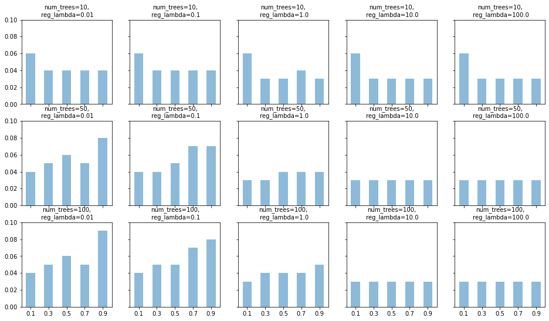

```python
res_df = pd.DataFrame(cv_results,
                      columns = ["param_n_estimators","param_learning_rate","param_reg_lambda","mean_test_score"])
# Note, MAE is made negative in the scikit-learn library so that it can be maximized.
# As such, we can ignore the sign and assume all errors are positive.
res_df['mean_test_score']=-res_df['mean_test_score'].values

fig, axes = plt.subplots(figsize=(16, 9),nrows=3, ncols=5)
ax_all = plt.gca()

cnt = 0
for param, tmp in res_df.groupby(["param_n_estimators", "param_reg_lambda"]):
    ax = axes[cnt//5][cnt%5] # get the ax
    np.round(tmp[["param_learning_rate","mean_test_score"]],2).plot.bar(ax=ax, x="param_learning_rate", y="mean_test_score",
                                            alpha=0.5,legend=None)
    ax.set_xlabel("") # no xlabel
    ax.set_ylim(0, 0.1) # set y range
    # adjust xtick labels / adjust ytick labels
    if cnt//5 < 2:
        ax.xaxis.set_ticklabels("")
    else:
        for label in ax.get_xticklabels():
            label.set_rotation(0);
    if cnt%5 > 0:
        ax.yaxis.set_ticklabels("")
    # set title
    ax.set_title(f"num_trees={param[0]},\n reg_lambda={param[1]}",fontsize=10);
    # update
    cnt =cnt+1
```

图 10.9：多组参数取值下误差指标（SME）的图示。图中的每一行对应 nrounds，每一列对应 lambda。

在图 10.9 中，主要信息是，当树的数量较少（nrounds=10）时，小学习率（$\eta=0.1$）会损害预测质量，这意味着算法学习不足。

网格搜索可以分两个阶段进行：第一阶段帮助定位感兴趣区域（损失/目标值最低的区域），随后用更细的网格参数值放大这些区域。根据上面的结果，这意味着应考虑较多学习器（超过 50 个，可能超过 100 个），并避免 $\eta=0.9$ 或 $\eta=0.8$ 这样的大学习率。

### 10.3.3 示例：贝叶斯优化

Python 提供了多个贝叶斯优化软件包，如 Scikit-optimize、PYMC 和 HyperOpt。这里使用 Scikit-optimize，因为它用途广泛，所需代码也较少。

与网格搜索一样，我们需要编写用于优化超参数的目标函数。

```python
from skopt import BayesSearchCV  # module for Bayesian optimisation on the scikit learn backend
search_spaces = params           # we use the param grid from previous section
opt = BayesSearchCV(estimator=model,          # Wrapping everything up into the Bayesian optimizer
                    search_spaces=search_spaces,
                    scoring='neg_mean_squared_error',
                    cv=2)                                   # cross validation with 2-fold, we keep it light for computing time sake
opt.fit(X_train,y_train)
cv_results_opt=pd.DataFrame(opt.cv_results_)
```

```python
print(f'Best Parameters using bayes opt: {opt.best_params_}')
```

```
Best Parameters using bayes opt: OrderedDict([('learning_rate', 0.1), ('n_estimators', 50), ('reg_lambda', 100.0)])
```

最终参数表明，抵制过拟合是明智的：较少的学习器数量和较大的惩罚似乎是最佳选择。为确认这些结果，我们以与上一节相同的方式绘制损失与超参数之间的关系。收集完平方平均误差后，就可以绘制它们。我们有意使用 3 个参数，因为它们的影响可以在同一张图上同时绘制。

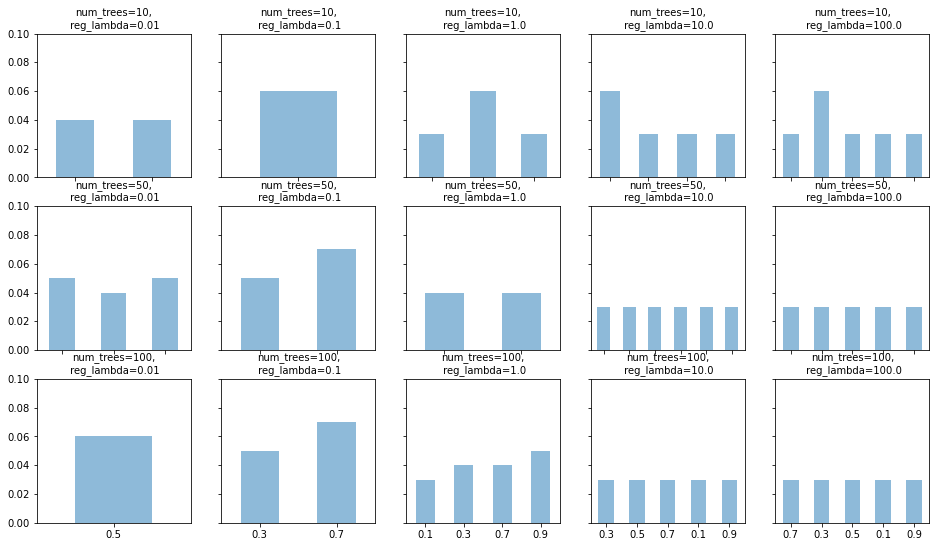

```python
res_df = pd.DataFrame(cv_results_opt,
                      columns = ["param_n_estimators","param_learning_rate","param_reg_lambda","mean_test_score"])
# Note, MAE is made negative in the scikit-learn library so that it can be maximized.
# As such, we can ignore the sign and assume all errors are positive.
res_df['mean_test_score']=-res_df['mean_test_score'].values

fig, axes = plt.subplots(figsize=(16, 9),nrows=3, ncols=5)
ax_all = plt.gca()

cnt = 0
for param, tmp in res_df.groupby(["param_n_estimators", "param_reg_lambda"]):
    ax = axes[cnt//5][cnt%5] # get the ax
    np.round(tmp[["param_learning_rate","mean_test_score"]],2).plot.bar(ax=ax, x="param_learning_rate", y="mean_test_score",
                                            alpha=0.5,legend=None)
    ax.set_xlabel("") # no xlabel
    ax.set_ylim(0, 0.1) # set y range
    # adjust xtick labels / adjust ytick labels
    if cnt//5 < 2:
        ax.xaxis.set_ticklabels("")
    else:
        for label in ax.get_xticklabels():
            label.set_rotation(0);
    if cnt%5 > 0:
        ax.yaxis.set_ticklabels("")
    # set title
    ax.set_title(f"num_trees={param[0]},\n reg_lambda={param[1]}",fontsize=10);
    # update
    cnt =cnt+1
```

图 10.10：多组参数取值下误差指标（SME）的图示。图中的每一行对应 nrounds，每一列对应 lambda。

## 10.4 关于验证回测的简短讨论

回测中的验证问题比看上去更复杂。事实上，它可以在两个尺度上运行，取决于预测模型是动态的（每次再平衡时更新）还是固定的。

先从第一种选项开始。在这种情况下，目标是构建一个唯一模型，并在不同时间段上测试它。关于适合用于这种情形的模型验证方法，仍存在持续争论。通常而言，在训练之后沿时间向前，在连续日期上测试模型是有意义的。这更合理，因为它复制了真实运行时会发生的情况。

在机器学习中，一种流行做法是把数据拆分为 $K$ 个分区，并测试 $K$ 个不同模型：每个模型在一个分区上测试，在其余 $K−1$ 个分区上训练。大多数专家（以及常识）都反对这种所谓**交叉验证**（CV），原因很简单：多数时候，训练集会包含来自未来日期的数据，却在过去值上测试。尽管如此，也有人主张某种特定形式的 CV，旨在确保训练集和测试集之间没有信息重叠（见 De Prado（2018）第 7.4 和 12.4 节）。其前提是，如果收益横截面的结构随时间保持不变，那么只要没有重叠，在未来点上训练并在过去数据上测试就不是问题。Schnaubelt（2019）的论文全面而详尽地梳理了多种验证方案。

De Prado（2018）引用的一个例子，是模型对未见过危机的反应。2008 年市场崩盘之后，至少 11 年没有发生重大金融震荡。测试近期模型对崩盘反应的一种方式，是在近年（例如 2015-2019 年）上训练它，并在 2008 年的多个时点（例如月份）上测试其表现。

第二个主要选项是模型在每次再平衡时更新（重新训练）。其基本思想是，收益结构会随时间演化，动态模型能够捕捉最近趋势。缺点是，验证必须（或者说应该？）在每个再平衡日期重新运行。

我们回顾一下回测的维度：

- **策略**数量：可能是几十、几百，甚至更多；
- 交易**日期**数量：月度再平衡时可达数百个；
- **资产**数量：数百或数千；
- **特征**数量：几十或几百。

即使拥有大量计算能力（GPU 等），在许多日期上训练许多模型也很耗时，尤其是在参数空间很大、需要超参数调优时。因此，在样本外期间的每个交易日期验证模型并不现实。

一种解决方案是保留训练数据的早期部分，并在这个子样本上执行较小规模的验证。超参数在有限数量的日期上测试，并且大多数时候会表现出稳定性：某个日期上令人满意的参数，通常也适用于下一个日期以及再下一个日期。因此，在每期更新模型时，可以用这些取值完成完整回测。不过回测仍然计算密集，因为模型必须在每个再平衡日期用最新数据重新训练。

### 参考文献

参考文献 Bergstra, James, and Yoshua Bengio. 2012. “Random Search for Hyper-Parameter Optimization.” Journal of Machine Learning Research 13 (Feb): 281–305.

Bouthillier, Xavier, and Gaël Varoquaux. 2020. “Survey of Machine-Learning Experimental Methods at Neurips2019 and Iclr2020.” Research Report. Inria Saclay Ile de France.

Breiman, Leo. 2001. “Random Forests.” Machine Learning 45 (1): 5–32.

De Prado, Marcos Lopez. 2018. Advances in Financial Machine Learning. John Wiley & Sons.

Frazier, Peter I. 2018. “A Tutorial on Bayesian Optimization.” arXiv Preprint, no. 1807.02811.

Gu, Shihao, Bryan T Kelly, and Dacheng Xiu. 2020b. “Empirical Asset Pricing via Machine Learning.” Review of Financial Studies 33 (5): 2223–73.

Hsu, Po-Hsuan, Qiheng Han, Wensheng Wu, and Zhiguang Cao. 2018. “Asset Allocation Strategies, Data Snooping, and the 1/N Rule.” Journal of Banking & Finance 97: 257–69.

Lee, Sang Il. 2020. “Hyperparameter Optimization for Forecasting Stock Returns.” arXiv Preprint, no. 2001.10278.

Li, Jia, Zhipeng Liao, and Rogier Quaedvlieg. 2020. “Conditional Superior Predictive Ability.” SSRN Working Paper 3536461.

Maclaurin, Dougal, David Duvenaud, and Ryan Adams. 2015. “Gradient-Based Hyperparameter Optimization Through Reversible Learning.” In International Conference on Machine Learning, 2113–22.

Nystrup, Peter, Erik Lindstrom, and Henrik Madsen. 2020. “Hyperparameter Optimization for Portfolio Selection.” Journal of Financial Data Science Forthcoming.

Probst, Philipp, Bernd Bischl, and Anne-Laure Boulesteix. 2018. “Tunability: Importance of Hyperparameters of Machine Learning Algorithms.” arXiv Preprint, no. 1802.09596.

Schnaubelt, Matthias. 2019. “A Comparison of Machine Learning Model Validation Schemes for Non-Stationary Time Series Data.” FAU Discussion Papers in Economics.

Snoek, Jasper, Hugo Larochelle, and Ryan P Adams. 2012. “Practical Bayesian Optimization of Machine Learning Algorithms.” In Advances in Neural Information Processing Systems, 2951–9.

White, Halbert. 2000. “A Reality Check for Data Snooping.” Econometrica 68 (5): 1097–1126.

1. 也有一些例外，例如尝试优化更少见的准则，如基于排序的 Spearman rho。它在精神上接近于最大化输出与预测之间的相关性。由于这个 rho 不可微，会造成数值问题。当采用复杂架构时，这些问题可以部分缓解，如 Engilberge 等（2019）。↩︎
2. Geman、Bienenstock 和 Doursat（1992）从批判神经网络的另一个角度提供了讨论。↩︎